# 실전 데이터분석

## 교통데이터를 이용한 실전데이터분석

TAAS 교통사고분석 시스템을 이용하여 2018년부터 2020년까지 대전에서 발생한 구별 교통사고 자료를 수집하였다.

자료를 R로 불러와 다음 문제를 풀어보세요.

자료를 다운 받은 경로를 `setwd`로 설정 후 이용하세요.

```r
library(readxl)
data1 <- read_excel("대전광역시_대덕구.xlsx")
data2 <- read_excel("대전광역시_동구.xlsx")
data3 <- read_excel("대전광역시_서구.xlsx")
data4 <- read_excel("대전광역시_서구2.xlsx")
data5 <- read_excel("대전광역시_중구.xlsx")

t.data1 <- rbind(data1, data2, data3, data4, data5)
```

일일히 자료를 불러오기 싫다면 `purrr` 패키지의 map_df 함수를 이용할 수 있습니다.

```r
library(dplyr)
library(purrr)

t.data2 <-
  list.files(pattern = "대전광역시") %>%
  map_df(~read_excel(.)) %>%
  data.frame

head(t.data2)
```

```
##           사고번호            사고일시   요일                   시군구
## 1 2018010100100186 2018년 1월 1일 10시 월요일 대전광역시 대덕구 오정동
## 2 2018010100100391 2018년 1월 1일 20시 월요일 대전광역시 대덕구 비래동
## 3 2018010100100403 2018년 1월 1일 21시 월요일 대전광역시 대덕구 평촌동
## 4 2018010100100404 2018년 1월 1일 21시 월요일 대전광역시 대덕구 중리동
## 5 2018010200100208 2018년 1월 2일 12시 화요일 대전광역시 대덕구 읍내동
## 6 2018010500100286 2018년 1월 5일 15시 금요일 대전광역시 대덕구 중리동
##       사고내용 사망자수 중상자수 경상자수 부상신고자수          사고유형
## 1     경상사고        0        0        3            0     차대차 - 추돌
## 2 부상신고사고        0        0        0            1   차대사람 - 기타
## 3     경상사고        0        0        2            0 차대차 - 측면충돌
## 4     중상사고        0        1        0            0 차대사람 - 횡단중
## 5     경상사고        0        0        1            0     차대차 - 기타
## 6     경상사고        0        0        2            0 차대차 - 측면충돌
##             법규위반    노면상태 기상상태            도로형태 가해운전자.차종
```

[output cut: 20 more lines]

### 1. 분석에 사용된 자료는 총 몇개인가요?

```
## [1] 17205
```

### 2. 연도별 대전광역시의 사고건 수를 확인하고 막대도표로 그리세요.

- 사고번호 또는 사고일시의 앞에 1번째부터 4번째까지 숫자를 가져오면 연도가 됩니다.
- substr()함수를 이용하면 임의의 위치의 문자를 가져올 수 있습니다.

```
##
## 2018 2019 2020
## 5554 6269 5382
```

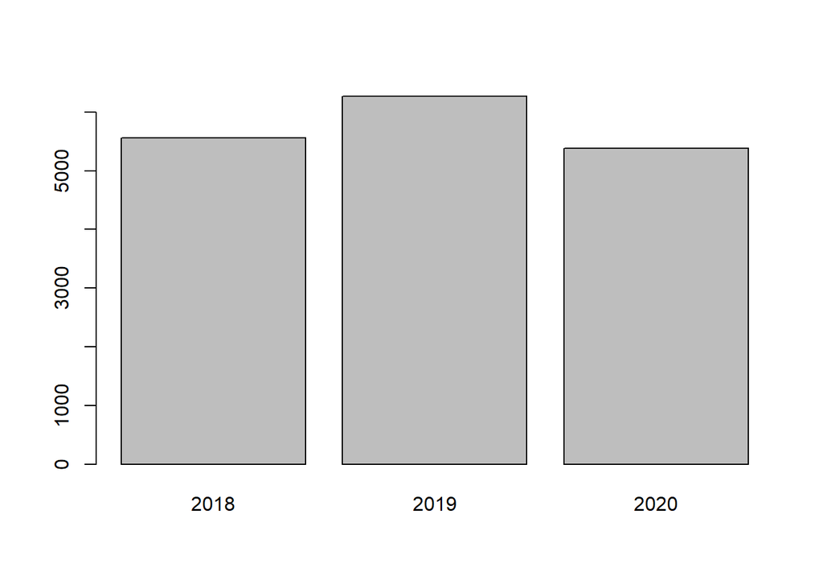

### 3. 연도별 월별 대전광역시 사고건수를 구하고자 합니다.

- mutate함수와 substr함수를 이용하여 연도(year)와 월(mon) 변수를 생성하세요.

```
##           사고번호            사고일시   요일                   시군구
## 1 2018010100100186 2018년 1월 1일 10시 월요일 대전광역시 대덕구 오정동
## 2 2018010100100391 2018년 1월 1일 20시 월요일 대전광역시 대덕구 비래동
## 3 2018010100100403 2018년 1월 1일 21시 월요일 대전광역시 대덕구 평촌동
## 4 2018010100100404 2018년 1월 1일 21시 월요일 대전광역시 대덕구 중리동
## 5 2018010200100208 2018년 1월 2일 12시 화요일 대전광역시 대덕구 읍내동
## 6 2018010500100286 2018년 1월 5일 15시 금요일 대전광역시 대덕구 중리동
##       사고내용 사망자수 중상자수 경상자수 부상신고자수          사고유형
## 1     경상사고        0        0        3            0     차대차 - 추돌
## 2 부상신고사고        0        0        0            1   차대사람 - 기타
## 3     경상사고        0        0        2            0 차대차 - 측면충돌
## 4     중상사고        0        1        0            0 차대사람 - 횡단중
## 5     경상사고        0        0        1            0     차대차 - 기타
## 6     경상사고        0        0        2            0 차대차 - 측면충돌
##             법규위반    노면상태 기상상태            도로형태 가해운전자.차종
```

[output cut: 20 more lines]

- table함수에 생성된 연도와 월 변수를 넣어 다음 표를 생성하세요.

```
##
##          1   2   3   4   5   6   7   8   9  10  11  12
##   2018 419 417 437 455 459 472 454 502 465 499 523 452
##   2019 450 469 489 525 640 526 546 536 481 571 542 494
##   2020 411 475 396 429 478 493 483 431 464 457 460 405
```

- 위에서 생성된 표를 막대도표로 그리세요.`beside=T, legend=rownames(table(q3$year, q3$mon))`를 추가로 사용

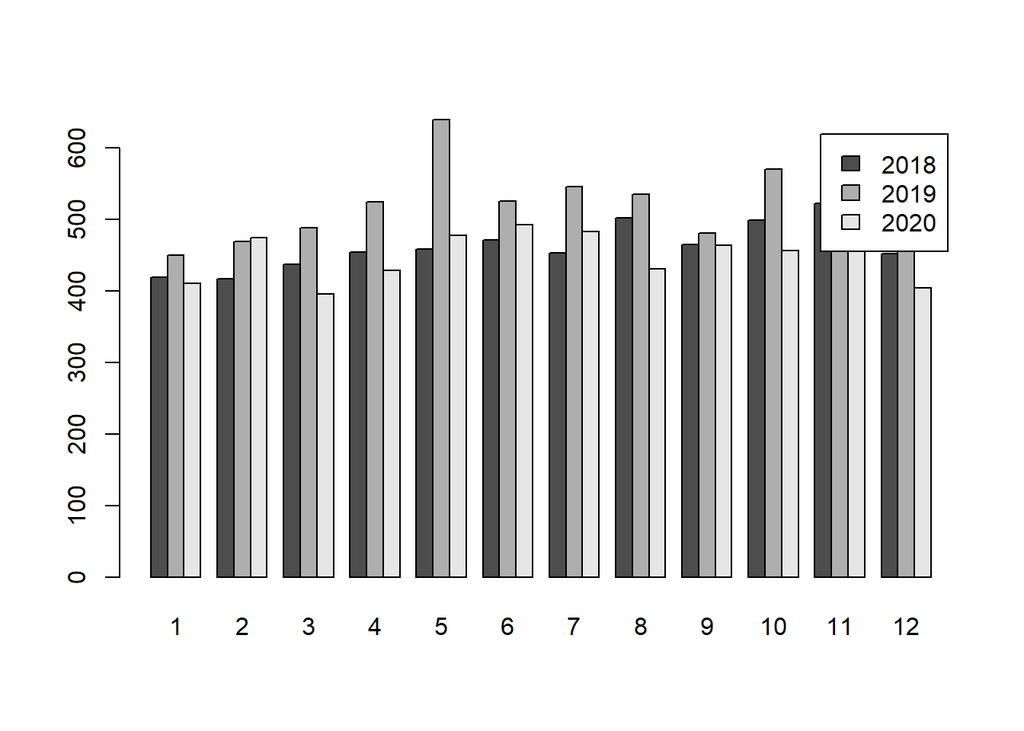

### 4. 대전광역시의 시간대별 경상자수를 구하세요.

- 시간대 파생변수를 substr()로 생성하세요.
- nchar는 문자열의 길이를 계산하는 함수입니다.
- 사고일시의 마지막에서 `시`만 제거하면 시간을 추출할 수 있습니다. `nchar(사고일시)-2, nchar(사고일시)-1)`
- group_by와 summarise를 이용하여 시간대별 경상자수를 구하고 막대도표로 그리세요.

```
##    hr 경상자
## 1   0    657
## 2   1    500
## 3   2    318
## 4   3    250
## 5   4    266
## 6   5    292
## 7   6    337
## 8   7    475
## 9   8   1030
## 10  9    859
## 11 10    784
## 12 11    942
## 13 12    915
## 14 13   1039
## 15 14   1054
## 16 15   1160
## 17 16   1192
## 18 17   1401
## 19 18   1560
## 20 19   1366
## 21 20   1088
## 22 21   1061
## 23 22    915
## 24 23    727
```

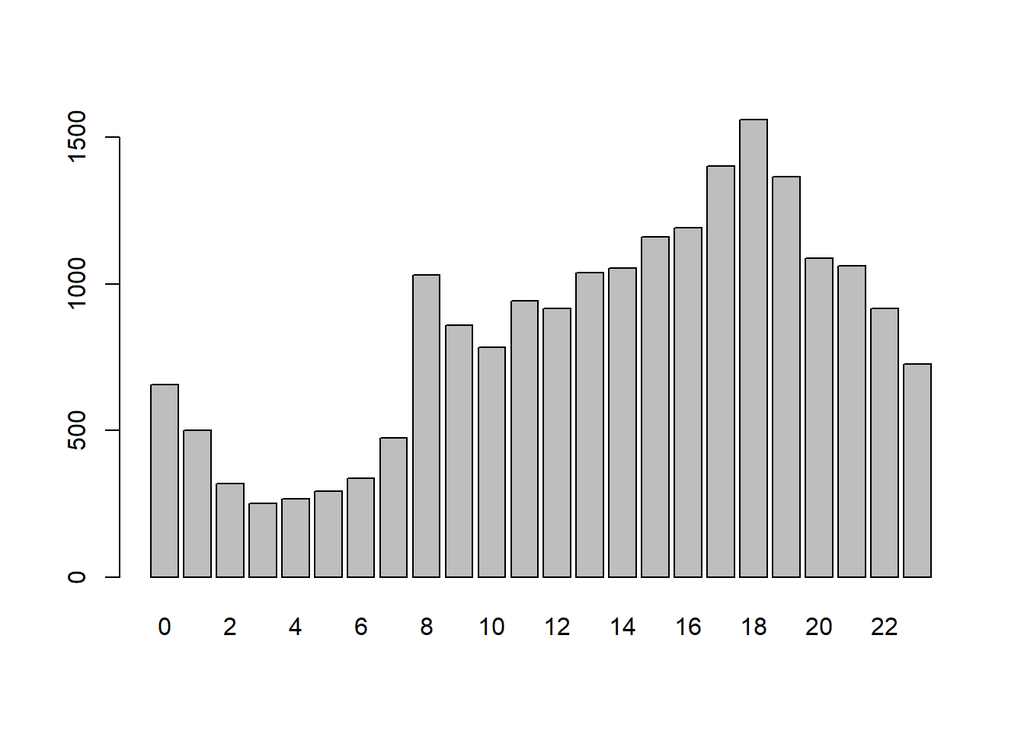

### 5. 교통사고의 원인인 법규위반의 빈도를 정렬하여 그리세요.

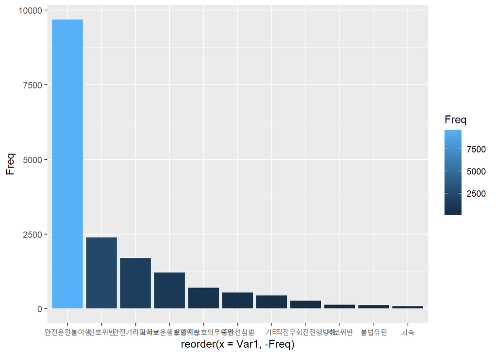

### 6. 사망사건 가해운전자의 성별은?

```
##
##  남  여
## 153  23
```